# What underlying patterns are associated with counties implementing sanctuary policies?

Authors: Kim Larson, Connor Warren

### Summary

A political party’s dominance over a state’s legislative lower house is the strongest predictor of a county’s U.S. Immigration and Customs Enforcement (ICE) cooperation policies when factoring in census information about county demographics, economic data including GDP by industry, and the political affiliation of elected officials at the state and federal levels.

```python
#| include: false
### Import Libaries

import pandas as pd
import seaborn as sns
import numpy as np
import matplotlib.pyplot as plt
# Machine learning libraries
from sklearn.ensemble import HistGradientBoostingClassifier, GradientBoostingClassifier
from sklearn.cluster import KMeans
from sklearn.preprocessing import OneHotEncoder
from sklearn.linear_model import LogisticRegression
from sklearn.model_selection import train_test_split, StratifiedKFold, cross_validate, ShuffleSplit
from sklearn.metrics import confusion_matrix, f1_score
from sklearn import tree
from sklearn.inspection import permutation_importance
from sklearn.feature_selection import SequentialFeatureSelector, RFECV
from sklearn.compose import make_column_selector as selector
# Data manipulation libraries for clustering
from scipy.cluster import hierarchy
from scipy.spatial.distance import squareform
from collections import defaultdict
import os
# Visualization libraries
from matplotlib.colors import ListedColormap, BoundaryNorm
from matplotlib.colors import TwoSlopeNorm
```

```python
#| include: false
### Set File Directory for a Mac

#Sets the working directly from Github repository to the correct data files
# Data source: https://github.com/wu-msds-capstones/pdx-project-workbook-connor-kim-capstone

child = os.getcwd()
parent = os.path.dirname(child) + '//shared_data'
os.chdir(parent)

### Set File Directory for a PC
#child = os.getcwd()
#parent = os.path.dirname(child) + '\\shared_data'
#os.chdir(parent)
```

```python
#| include: false

# Assign colors to each ILRC score
ilrc_colors = {
    '0 points': '#ad0907',
    '1 points': '#f36321',
    '2 points': '#ffb52b',
    '3 points': '#ffeb3a',
    '4 points': '#d3e670',
    '5 points': '#85d12d',
    '6 points': '#5b9412',
    '7 points': '#244d13'
}
```

## Background

This project examines the relationship between local economic, demographic, and political factors and county-level immigration policy, utilizing data from the ILRC, U.S. Census, Bureau of Economic Analysis, and electoral outcomes.

We developed predictive models to identify which county features are most strongly associated with how the county cooperates or resists assisting federal immigration detention. The findings offer insight into the structural patterns that may influence immigration-related policy decisions at the county level.

The Immigration Legal Resource Center (ILRC) was founded as the Golden Gate Immigration Clinic in 1979 to address the growing need for expert assistance and training in immigration law and policy, following the increasingly complex legal and social challenges that immigrants faced. The ILRC aims to enhance immigration law and policy, expand the capabilities of legal service providers, and promote immigrant rights by training attorneys, paralegals, and community-based advocates who work with immigrants nationwide. The organization also informs elected officials and the public on shaping effective and just immigration policy and law.

In November 2019, the ILRC published a National Map of Local Entanglement with ICE, which assigned each county a score from 0 to 7. Counties with scores of 0 represent those that are most entangled with ICE, identified for spending “substantial local time and resources on civil immigration enforcement, [including those] under a 287(g) agreement.” A 287(g) agreement is a contract with ICE that delegates enforcement authority to state and local law enforcement agencies.

Counties with scores of 7 represent counties that are least entangled, and identified for having “the most comprehensive protections to prevent local resources from going to civil immigration enforcement.” Counties with no jail are assigned a score of 8, and counties with no available data receive no score and were dismissed from the scope of this research.

Multnomah County in Oregon was assigned an ILRC score of 6, which was generated by the sum of ‘Yes’ to the following policy metrics:

| Policy Type | Metric | Multnomah County Points |
| --- | --- | --- |
| Passive | Declines 287(g) Program | Yes |
| Passive | Declines ICE detention contract | Yes |
| Active | Limits ICE holds | Yes |
| Active | Limits ICE notifications | Yes |
| Active | Limits on ICE interrogations in jail | No |
| Active | Prohibition on asking immigration status | Yes |
| Active | General Prohibition on Assistance to ICE | Yes |

We differentiated policy types as either active or passive policies. Passive policies accumulate points when counties take no action to cooperate with ICE. Active policies accumulate points when counties take proactive measures to protect local resources from aiding ICE efforts. For example, declining a 287(g) agreement is considered a passive policy because the county must actively agree to the contract for it to be in place. In contrast, limiting ICE notifications is a proactive measure counties must take to prevent ICE from benefiting from local resources.

By combining county and state policy data from the ILRC with publicly available census and elected official political affiliation data, we aimed to gain a deeper understanding of how elected officials at different levels of government are associated with various immigration policies.

```python
#| include: false
# Voting for Presidential Elections

# Import county voting history for presidential elections from 2008 to 2024
elec = pd.read_csv('fed_election_county.csv', index_col = 'Unnamed: 0', dtype = {'fips_code' : str})

# Drop the redundant columns
elec_county = elec.drop(columns = ['year', 'county']).groupby(by = ['fips_code']).sum()

# Add the percentage of votes cast per party and calculate the difference
elec_county['per_gop'] = (elec_county['gop'] / elec_county['total']) * 100
elec_county['per_dem'] = (elec_county['dem'] / elec_county['total']) * 100
elec_county['net'] = (elec_county['per_gop'] - elec_county['per_dem'])

#print(elec.head())
```

```python
#| include: false
# 2025 Governor Data

# Import the governor data and drop unnecessary columns
gov = pd.read_csv('gov.csv', dtype = str).drop(columns = 'Governor Born')

gov['Gov Party'] = gov['Gov Party'].map(lambda x: 'gop' if x == 'Republican' else 'dem')

#print(gov.head())
```

```python
#| include: false
#2025 Legislative Data

# Import the legislative data and assign data types
leg = pd.read_csv('leg_cleaner.csv', dtype = {'LH Size' : int, 'UH Size' : int, 'LH Minority Number' : int, 'UH Minority Number' : int,
                                     'LH Majority Seats' : int, 'UH Majority Seats' : int})


# Assign party seat counts
leg.loc[(leg['LH Party'] == 'gop'), 'LH_gop_seats'] = leg['LH Majority Seats']
leg.loc[(leg['LH Party'] == 'dem'), 'LH_gop_seats'] = leg['LH Minority Number']
leg.loc[(leg['LH Party'] == 'gop'), 'LH_dem_seats'] = leg['LH Minority Number']
leg.loc[(leg['LH Party'] == 'dem'), 'LH_dem_seats'] = leg['LH Majority Seats']

leg.loc[(leg['UH Party'] == 'gop'), 'UH_gop_seats'] = leg['UH Majority Seats']
leg.loc[(leg['UH Party'] == 'dem'), 'UH_gop_seats'] = leg['UH Minority Number']
leg.loc[(leg['UH Party'] == 'gop'), 'UH_dem_seats'] = leg['UH Minority Number']
leg.loc[(leg['UH Party'] == 'dem'), 'UH_dem_seats'] = leg['UH Majority Seats']


#Compute party control percentages
leg['dem_control_lh'] = (leg['LH_dem_seats'] / leg['LH Size']) * 100
leg['dem_control_uh'] = (leg['UH_dem_seats'] / leg['UH Size']) * 100
leg['gop_control_lh'] = (leg['LH_gop_seats'] / leg['LH Size']) * 100
leg['gop_control_uh'] = (leg['UH_gop_seats'] / leg['UH Size']) * 100


#Compute party point percentages
leg['pt_diff_lh'] = leg['gop_control_lh'] - leg['dem_control_lh']
leg['pt_diff_uh'] = leg['gop_control_uh'] - leg['dem_control_uh']


#Drop unnecessary columns
leg = leg.drop(columns = ['LH Minority Number', 'UH Minority Number', 'LH Majority Seats', 'UH Majority Seats'])
leg = leg[['STATE_CODE', 'pt_diff_lh', 'pt_diff_uh', 'LH Party', 'UH Party']]

#print(leg.head())
```

```python
#| include: false
#Combine Governor and Legislative Data

# Create state by combining Governor and Legislative data
state = pd.merge(gov, leg, how = 'inner', on = 'STATE_CODE').rename(columns = {'STATEFP' : 'state'})

#print(state.head())
```

```python
#| include: false
# Import Population Data

# Create naming dictionary
new_names = {
    'Foreign-born Population Estimate' : 'FB_popE',
    'Foreign-born Population Margin' : 'FB_popM',
    'Non-citizen Pop Estimate' : 'NC_popE',
    'Non-citizen Pop Margin' : 'NC_popM',
    'Lived in Different House Estimate' : 'diff_houseE',
    'Lived in Different House Margin' : 'diff_houseM',
    'Total Population Estimate': 'total_popE',
    'Total Population Margin' : 'total_popM'}

# Import census data
acs = pd.read_csv('acs_data.csv', dtype = {'state' : str, 'county' : str}).drop(columns = 'Unnamed: 0').rename(columns = new_names)

# Create FIPS code
acs['fips_code'] = acs['state'] + acs['county']

# Filter for valid migration estimates
acs = acs[acs['diff_houseE'] > 0]

# Drop unnecessary columns and group by FIPS code
acs_county = acs.drop(columns = ['NAME', 'county', 'Year', 'state', 'FB_popM', 'NC_popM', 'diff_houseM', 'total_popM']).groupby(['fips_code']).mean()

#print(acs.head())
```

```python
#| include: false
# Import Economic Data

# Import the Bureau of Economic Analysis
bea = pd.read_csv('econ_bea.csv', dtype = {'GeoFips' : str}).rename(columns = {'GeoFips' : 'fips_code', 'TimePeriod' : 'year'})

# Normalize FIPS codes to 5 characters
bea = bea.assign(fips_code = lambda bea: bea['fips_code'].map(lambda fips_code: fips_code if len(fips_code) == 5 else '0' + fips_code))

# Group economic data by industry
bea_gdp = bea.loc[bea['Code'] == 'CAGDP2-1'].drop(columns = ['primary_key','UNIT_MULT','Code', 'year', 'GeoName']).groupby(by = ['fips_code']).mean().rename(columns = {'DataValue' : 'GDP'})
bea_con = bea.loc[bea['Code'] == 'CAGDP2-11'].drop(columns = ['primary_key','UNIT_MULT','Code', 'year', 'GeoName']).groupby(by = ['fips_code']).mean().rename(columns = {'DataValue' : 'Construction'})
bea_manu = bea.loc[bea['Code'] == 'CAGDP2-12'].drop(columns = ['primary_key','UNIT_MULT','Code', 'year', 'GeoName']).groupby(by = ['fips_code']).mean().rename(columns = {'DataValue' : 'Manufacturing'})
bea_agri = bea.loc[bea['Code'] == 'CAGDP2-3'].drop(columns = ['primary_key','UNIT_MULT','Code', 'year', 'GeoName']).groupby(by = ['fips_code']).mean().rename(columns = {'DataValue' : 'Agriculture'})
bea_rerl = bea.loc[bea['Code'] == 'CAGDP2-56'].drop(columns = ['primary_key','UNIT_MULT','Code', 'year', 'GeoName']).groupby(by = ['fips_code']).mean().rename(columns = {'DataValue' : 'Real_Estate'})
bea_rex = bea.loc[bea['Code'] == 'CAGDP2-6'].drop(columns = ['primary_key','UNIT_MULT','Code', 'year', 'GeoName']).groupby(by = ['fips_code']).mean().rename(columns = {'DataValue' : 'Resource_Extraction'})
bea_county = pd.concat([bea_gdp, bea_con, bea_manu, bea_agri, bea_rerl, bea_rex], axis = 1)

#print(bea.head())
```

```python
#| include: false
# Import Policy Data

# Create naming dictionary
new_ilrc = {'5 Digit FIPS' : 'fips_code',
       'Declines 287(g) Program' : 'declines_287',
       'Declines ICE Detention Contract' : 'declines_ICE_contract',
       'Limits ICE Holds' : 'limits_ICE_hold',
       'Limits ICE notifications' : 'limits_ICE_notif',
       'Limits on ICE interrogations in jail' : 'limits_ICE_interrogation',
       'Prohibition on asking about immigration status' : 'prohibit_asking_status',
       'General prohibition on assistance to ICE' : 'general_prohibit_on_assistance'}

# Import ILRC county map
ilrc = pd.read_csv('ilrc_cleaned.csv', dtype = {'5 Digit FIPS' : str}).rename(columns = new_ilrc)

# Separate score and comments and drop comments from original
ilrc_comments = ilrc[['ILRC Total', '2015 ICE Comments', '2017 ICE Comments', 'fips_code']]
ilrc = ilrc.drop(columns = ['2015 ICE Comments', '2017 ICE Comments', 'County', 'State'])

#print(ilrc.head())
```

```python
#| include: false
# Normalize the population, economic, and election data

# Create points dictionary
ilrc_points = ['declines_287','declines_ICE_contract','limits_ICE_hold', 'limits_ICE_notif', 'limits_ICE_interrogation',
               'prohibit_asking_status', 'general_prohibit_on_assistance']

# Demographic estimates
acs_es = ['per_fb', 'per_nc', 'moved_from_diff_county_per']

#Economic variables
bea_cols = ['Con/GDP', 'Agri/GDP', 'Manu/GDP', 'Real_Estate/GDP', 'Resource_Extraction/GDP', 'GDP_per_capita']

# Election variables
elec_cols = ['per_gop', 'per_dem', 'net']
```

```python
#| include: false

# Merge election and economic data on the county FIPS codes
agg_data = pd.merge(elec_county, bea_county, on = 'fips_code', how = 'inner').merge(acs_county, on = 'fips_code', how = 'inner').merge(ilrc, on = 'fips_code', how = 'inner')

agg_data['state'] = agg_data['fips_code'].str[:2]

agg_data = agg_data[agg_data['ILRC Total'] != 8]

agg_data_plus = agg_data.merge(state, on = 'state', how = 'inner').drop(columns = ['Governor', 'state', 'Inauguration', 'End of term'])

#print(agg_data_plus.head())
```

## Methods

### Data Engineering

Governmental and non-governmental agencies' data was used for this project, including directly from the U.S. Census Bureau, the Bureau of Economic Analysis, as well as indirectly from Wikipedia and GitHub. For this project, we focused on county-level information, including election results, immigration policies, and population demographic data. We contextualized it with relevant state data, such as the governor’s political party affiliation.

#### Policy Data:

The Immigrant Legal Resource Center (ILRC) published a map of local entanglement with U.S. Immigration and Customs Enforcement (ICE). We extracted the immigration policy dataset from the rendered map by inspecting the page and downloading the .csv file from the HTML. The dataset includes the ILRC score, policy type, county name, and ILRC comments.

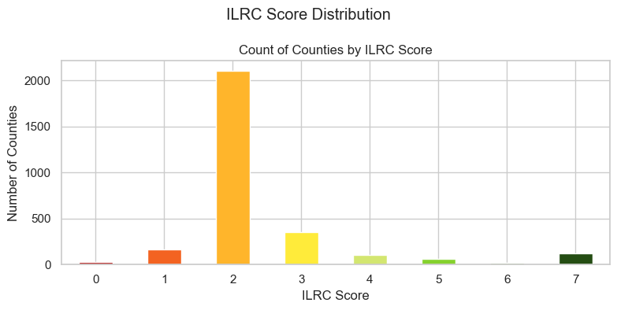

```python
#| echo: false
plt.figure(figsize=(8, 4))

# Plot as a Series so each bar uses a different color
ilrc_counts = ilrc['ILRC Total'].value_counts().sort_index()
ilrc_counts = ilrc_counts.reindex(range(0, 8), fill_value=0)


# Use a list of colors from ilrc_colors for the bars, only for 0-7 points
bar_colors = [ilrc_colors[f"{i} points"] for i in ilrc_counts.index]
ilrc_counts.plot(kind='bar', stacked=True, color=bar_colors)

#Titles and labels
plt.suptitle('ILRC Score Distribution')
plt.title('Count of Counties by ILRC Score')
plt.xlabel('ILRC Score')
plt.ylabel('Number of Counties')
plt.xticks(rotation=0)
plt.tight_layout()
plt.show()
```

Counties that are operating with no changes to their policies will default to a score of 2. To achieve a score of 0 or 1, counties must forfeit their passive points by actively deciding to route local resources to ICE. To achieve a score of 3 or higher, counties must have implemented active policies that prevent ICE from utilizing local resources.

#### Population Demographics:

Population data enabled us to determine to what degree the population demographics of a county could predict the adoption of the policies that contributed to the ILRC scores.

The population data was taken from the American Community Survey (ACS) 5-year survey and retrieved through the Census Bureau’s API for the ACS. The Census Bureau also provided the essential index tables for counties and state codes. The Census Bureau recommends using non-overlapping years for these comparisons, so only the datasets from 2023, 2018, and 2013 were included, which span the years from 2009 to 2023. The API returned the data in JSON format at the county level, which was then converted into tidy tabular data, with each row representing a county in a specific period, using pandas.

Population data by the Census collected at the county level includes: county name, Foreign-born Population Estimate, Foreign-born Population Margin, Non-citizen Pop Estimate, Non-citizen Pop Margin, Lived in Different House Estimate, Lived in Different House Margin, Total Population Estimate, Total Population Margin, state, county, and the year the data was collected from 2013 to 2023.

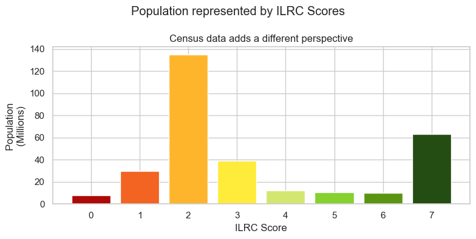

```python
#| echo: false

# Merge ILRC policy data with ACS population data
ILRC_pop = pd.merge(ilrc, acs_county, on='fips_code', how='inner')

# Group by ILRC score and sum total population estimates
pop_by_ilrc = ILRC_pop.groupby('ILRC Total')['total_popE'].sum().reindex(range(0, 8), fill_value=0)

# Format population in millions for readability
pop_by_ilrc_millions = pop_by_ilrc / 1_000_000
bar_colors = [ilrc_colors[f"{i} points"] for i in pop_by_ilrc_millions.index]

plt.figure(figsize=(8, 4))

x = pop_by_ilrc_millions.index
heights = pop_by_ilrc_millions.values
bar_colors = [ilrc_colors[f"{i} points"] for i in x]

plt.bar(x=x, height=heights, color=bar_colors)

plt.suptitle('Population represented by ILRC Scores')
plt.title('Census data adds a different perspective')
plt.xlabel('ILRC Score')
plt.ylabel('Population \n(Millions)')
plt.xticks(ticks=x, labels=x)
plt.tight_layout()
plt.show()
```

By joining the ILRC policy data with the ACS population data, we recognize that despite very few counties having a score of 0 or 6, a proportionally higher number of people are living within counties with those scores. This suggests that counties with higher populations are more likely to have taken proactive measures in determining how they will or will not cooperate with ICE.

**Election & Economic Data:**

To add another perspective to the analysis beyond census data, we included election results and economic data to see if there was strong predictive power with those dimensions.

Election data was taken from a diverse portfolio of publicly available online sources. Data were copied from state government websites for the political affiliation of state governors and the composition of the state legislative branches.

For county-level results for presidential election cycles, a GitHub repository contains the results of every presidential election at the county level since 2008. The data concerning the partisanship of state governments was converted into a tabular format, and the election data was already in a tidy format at the county level.

To standardize the data, third-party officials were tabulated with Democrats as non-Republicans, following the caucus behaviors in Alaska and Vermont. The data was pulled prior to the assassination of Democratic Speaker of the House Melissa Hortman in June 2025, which flipped Minnesota’s lower house majority from Democrat control by a single seat margin to being evenly split.

The Bureau of Economic Analysis (BEA) data was pulled using their API endpoints. The BEA data provided data on economic activities in a given county, which was filtered to include the fields of interest and overall county GDP. The datasets were converted from JSON format to tidy tabular data and normalized to include GDP per Capita.

```python
#| include: false
#Normalize the data for economy and population sizes


# Make a copy of the aggregated election dataframe
agg_data_norm = agg_data[['fips_code', 'state', 'per_gop', 'per_dem', 'net', 'ILRC Total', 'declines_287','declines_ICE_contract','limits_ICE_hold', 'limits_ICE_notif', 'limits_ICE_interrogation', 'prohibit_asking_status', 'general_prohibit_on_assistance']].copy()

# Normalize the GDP Contributions across counties of different economic sizes
agg_data_norm['Con/GDP'] = (agg_data['Construction'] / agg_data['GDP']) * 100
agg_data_norm['Agri/GDP'] = (agg_data['Agriculture'] / agg_data['GDP']) * 100
agg_data_norm['Manu/GDP'] = (agg_data['Manufacturing'] / agg_data['GDP']) * 100
agg_data_norm['Real_Estate/GDP'] = (agg_data['Real_Estate'] / agg_data['GDP']) * 100
agg_data_norm['Resource_Extraction/GDP'] = (agg_data['Resource_Extraction'] / agg_data['GDP']) * 100

# Calculate the average economic out per person with GDP per capita
agg_data_norm['GDP_per_capita'] = agg_data['GDP']/agg_data['total_popE']

# Normalize demographic features
agg_data_norm['per_fb'] = (agg_data['FB_popE'] / agg_data['total_popE']) * 100
agg_data_norm['per_nc'] = (agg_data['NC_popE'] / agg_data['total_popE']) * 100
agg_data_norm['moved_from_diff_county_per'] = (agg_data['diff_houseE'] / agg_data['total_popE']) * 100

# Normalize ILRC scores as a string to work around seaborn's inability to plot integers as categorical variables
agg_data_norm['ILRC Total'] = agg_data_norm['ILRC Total'].astype(str) + ' points'
# Order the ILRC scores for better visualization
agg_data_norm['ILRC Total'] = pd.Categorical(agg_data_norm['ILRC Total'],
                                              categories=['0 points', '1 points', '2 points', '3 points',
                                                          '4 points', '5 points', '6 points', '7 points'],
                                              ordered=True)



# Merges county data with state data
agg_data_norm_plus = agg_data_norm.merge(state, on = 'state', how = 'inner').drop(columns = ['STATE_CODE', 'Governor', 'state', 'Inauguration', 'End of term'])

#print(agg_data_norm.head())
```

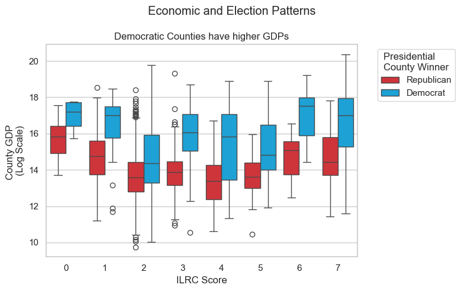

```python
#| echo: false

# Ensure GDP is positive before applying log
agg_data_plus = agg_data_plus[agg_data_plus['GDP'] > 0]
agg_data_plus['log_GDP'] = np.log(agg_data_plus['GDP'])

# Create a binary label for who won the county
agg_data_plus['Elec_winner'] = np.where(agg_data_plus['per_gop'] > agg_data_plus['per_dem'], 'Republican', 'Democrat')

# Set plot style
sns.set(style='whitegrid', palette='muted')

# Create boxplot with custom palette
plt.figure(figsize=(8, 5))
sns.boxplot(
	data=agg_data_plus,
	x='ILRC Total',
	y='log_GDP',
	hue='Elec_winner',
	palette={'Republican': '#E81B23', 'Democrat': '#00AEF3'}
)


# Set labels and title
plt.suptitle('Economic and Election Patterns')
plt.title('Democratic Counties have higher GDPs')
plt.xlabel('ILRC Score')
plt.ylabel('County GDP \n(Log Scale)')


# Legend outside the plot
plt.legend(title='Presidential \nCounty Winner', bbox_to_anchor=(1.05, 1), loc='upper left')

plt.tight_layout()
plt.show()
```

This shows us an interesting pattern that for any given ILRC score, counties that voted for the Democratic presidential candidate in the most recent election have higher GDPs than those that voted for the Republican candidate.

#### Final Aggregations & Normalization

To make county-level comparisons, we aggregated the county-level data from the ACS, the BEA, and the election data. The demographic and economic features were averaged across the period under study, while the election data were summed.

We normalized the data to compute the ratio of each industry to the overall county GDP, the GDP per capita, and the proportion of the total population that was in each demographic category. Lastly, we merged the normalized data with the state-level datasets.

```python
#| include: false

# Hyperparameters

seed = 77
train = .8
log_reg_iters = 100
lr = 0.1
```

::: {.content-hidden}

### Experiment 1: Compare Graident Boosting, Logistic Regression, and Decision Trees

Results: Gradient Boosting was most effective as determined by highest average results score.

Results : pending cross validation

:::

```python
#| include: false
# Take agg_data_norm and drop the ILRC points and the ILRC Total column
x1 = agg_data_norm.drop(columns = ilrc_points).drop(columns = ['ILRC Total'])
```

```python
#| include: false
# Experiment 1.1 Boosting
models_boost = {} #saves the model object, f1 score, and confusion matrix for each subpoint for later reference

for point in ilrc_points:
    y = agg_data_norm[point]
    clf = GradientBoostingClassifier()
    shuffle = ShuffleSplit(5, train_size = train)
    cv_results = cross_validate(clf, x1, y, cv=shuffle, scoring=('f1'), return_train_score = False)
    f1_means = cv_results['test_score'].mean()
    models_boost[point] = (clf, f1_means)
```

```python
#| include: false
# Experiment 1.2 logistic regression
models_log = {} #saves the model object, f1 score, and confusion matrix for each subpoint for later reference

for point in ilrc_points:
    y = agg_data_norm[point]
    clf = LogisticRegression(max_iter = log_reg_iters, solver = 'newton-cholesky')
    shuffle = ShuffleSplit(5, train_size = train)
    cv_results = cross_validate(clf, x1, y, cv=shuffle, scoring=('f1'), return_train_score = False)
    f1_means = cv_results['test_score'].mean()
    models_log[point] = (clf, f1_means)
```

```python
#| include: false
# Experiment 1.3 decision trees
models_tree = {} #saves the model object, f1 score, and confusion matrix for each subpoint for later reference

for point in ilrc_points:
    y = agg_data_norm[point]
    clf = tree.DecisionTreeClassifier()
    shuffle = ShuffleSplit(5, train_size = train)
    cv_results = cross_validate(clf, x1, y, cv=shuffle, scoring=('f1'), return_train_score = False)
    f1_means = cv_results['test_score'].mean()
    models_tree[point] = (clf, f1_means)
```

```python
#| include: false
# Experiment 1 Results

for point in ilrc_points:
    print(point)
    boost_score = str(round(models_boost[point][1], 2))
    log_reg_score =  str(round(models_log[point][1], 2))
    tree_score = str(round(models_tree[point][1], 2))
    print('Boosting: ' + boost_score  + '\tLog_Reg: ' + log_reg_score + '\tDecision_Tree: ' + tree_score)
```

```
declines_287
Boosting: 0.98	Log_Reg: 0.98	Decision_Tree: 0.97
declines_ICE_contract
Boosting: 0.97	Log_Reg: 0.97	Decision_Tree: 0.94
limits_ICE_hold
Boosting: 0.79	Log_Reg: 0.43	Decision_Tree: 0.67
limits_ICE_notif
Boosting: 0.77	Log_Reg: 0.36	Decision_Tree: 0.68
limits_ICE_interrogation
Boosting: 0.85	Log_Reg: 0.38	Decision_Tree: 0.81
prohibit_asking_status
Boosting: 0.84	Log_Reg: 0.31	Decision_Tree: 0.8
general_prohibit_on_assistance
Boosting: 0.93	Log_Reg: 0.34	Decision_Tree: 0.84
```

### Machine Learning

Attempting to predict the overall ILRC score from the data is a single multivariate classification problem, which can be simplified into seven binary classification problems. In this approach, we use the data to predict each ILRC point individually, as the overall score is the sum of the individual ILRC points. After this simplification, we tested three classification models from the scikit-learn library in Python: GradientBoostingClassifier, LogisticRegression, and DecisionTreeClassifier. Utilizing five-fold cross-validation, we found that the GradientBoostingClassifier performed best overall when fitted on the normalized county-level data.

::: {.content-hidden}

| Policy | Boosting Score | Logistic Regression Score | Decision Tree Score |
| --- | --- | --- | --- |
| Declines 287 | 0.98 | **0.99** | 0.97 |
| Declines ICE contract | 0.96 | **0.97** | 0.94 |
| Limits ICE holds | **0.77** | 0.46 | 0.65 |
| Limits ICE notifications | **0.76** | 0.37 | 0.63 |
| Limits ICE interrogation | **0.87** | 0.40 | 0.78 |
| Prohibit asking status | **0.81** | 0.33 | 0.75 |
| General prohibit on assistance | **0.94** | 0.32 | 0.84 |

:::

::: {.content-hidden}

### Experiment 3: Gradient Boosting Classifier - Reducing Features

If we just use one of the dimentions of the data, such as the population data, economic data, or the election data, how effective are those metrics on their own to predict the individual identified ILRC policies.

Results : pending cross validation

:::

```python
#| include: false
# Eliminate categories of data to prevent data leakage between the ILRC points, total, and fips_code
x_acs = agg_data_norm.drop(columns = ilrc_points).drop(columns = ['ILRC Total', 'fips_code']).drop(columns = bea_cols +  elec_cols)
x_bea = agg_data_norm.drop(columns = ilrc_points).drop(columns = ['ILRC Total', 'fips_code']).drop(columns = acs_es +  elec_cols)
x_elec = agg_data_norm.drop(columns = ilrc_points).drop(columns = ['ILRC Total', 'fips_code']).drop(columns = bea_cols +  acs_es)

# Save the models for each subpoint, f1, and confusion matrix
model_acs = {}
model_bea = {}
model_elec = {}

for point in ilrc_points:
    y = agg_data_norm[point]
    clf = GradientBoostingClassifier(learning_rate = lr)
    shuffle = ShuffleSplit(5, train_size = train)

    cv_results_acs = cross_validate(clf, x_acs, y, cv=shuffle, scoring=('f1'), return_train_score = False)
    f1_means_acs = cv_results_acs['test_score'].mean()

    cv_results_bea = cross_validate(clf, x_bea, y, cv=shuffle, scoring=('f1'), return_train_score = False)
    f1_means_bea = cv_results_bea['test_score'].mean()

    cv_results_elec = cross_validate(clf, x_elec, y, cv=shuffle, scoring=('f1'), return_train_score = False)
    f1_means_elec = cv_results_elec['test_score'].mean()

    model_acs[point] = (clf, f1_means_acs)
    model_bea[point] = (clf, f1_means_bea)
    model_elec[point] = (clf, f1_means_elec)
```

```python
#| include: false
# Experiment 3 Results

for point in ilrc_points:
    print(point)
    acs = str(round(model_acs[point][1], 2))
    bea = str(round(model_bea[point][1], 2))
    elec = str(round(model_elec[point][1], 2))
    print('W/o ACS: ' + acs  + '\tW/o BEA: ' + bea + '\tW/o Election: ' + elec)
```

```
declines_287
W/o ACS: 0.98	W/o BEA: 0.98	W/o Election: 0.99
declines_ICE_contract
W/o ACS: 0.96	W/o BEA: 0.97	W/o Election: 0.97
limits_ICE_hold
W/o ACS: 0.81	W/o BEA: 0.81	W/o Election: 0.79
limits_ICE_notif
W/o ACS: 0.8	W/o BEA: 0.76	W/o Election: 0.83
limits_ICE_interrogation
W/o ACS: 0.84	W/o BEA: 0.89	W/o Election: 0.9
prohibit_asking_status
W/o ACS: 0.83	W/o BEA: 0.81	W/o Election: 0.85
general_prohibit_on_assistance
W/o ACS: 0.97	W/o BEA: 0.98	W/o Election: 0.93
```

::: {.content-hidden}

[output not shown]

:::

::: {.content-hidden} This test is to determine which of the features, population demographics, election results, or GDP, is most predictive in the ILRC policies. Note: Many of these factors are colinear, which is addressed in Experiment 10.

:::

::: {.content-hidden}

### Experiment 9: Gradient Boosting Classifier - Normalized

After looking at aggreated data, this dataset normalizes industry GDP according to population size and overall GDP.

Results:

:::

```python
#| include: false
# Separating out categorical and numeric

x9 = agg_data_norm_plus.drop(columns = ilrc_points + ['fips_code','ILRC Total']) # drops columns to prevent leakage
sel = selector(dtype_include=object) # creates selector for objects
cat_cols = sel(x9) # performs selection
x9_cat = x9[cat_cols] # selects categorical columns
x9_num = x9.drop(columns = cat_cols) # selects numerical columns
encoder = OneHotEncoder(sparse_output = False).set_output(transform = 'pandas') # creates encoder
encoded_cats = encoder.fit_transform(x9_cat) # encodes categorical columns
```

```python
#| include: false
# Runs the model iteratively for each ilrc point
x9_all = pd.merge(x9_num, encoded_cats, left_index= True, right_index = True) # recombines the two parts of the data frame

for point in ilrc_points:
    y = agg_data_norm_plus[point]
    clf = GradientBoostingClassifier()
    shuffle = ShuffleSplit(5, train_size = train)
    cv_results = cross_validate(clf, x9_all, y, cv=shuffle, scoring=('precision', 'recall', 'f1'), return_train_score = False)
    test_results = pd.DataFrame(np.array([cv_results['test_precision'], cv_results['test_f1'], cv_results['test_recall']]).transpose()).rename(columns = {0 : 'Precision', 1 : 'F1', 2: 'Recall'})
    print(point)
    print(test_results)
```

```
declines_287
   Precision        F1    Recall
0   0.967972  0.978417  0.989091
1   0.973592  0.986619  1.000000
2   0.968254  0.983871  1.000000
3   0.962766  0.977498  0.992687
4   0.977113  0.988424  1.000000
declines_ICE_contract
   Precision        F1    Recall
0   0.930973  0.962489  0.996212
1   0.943162  0.966333  0.990672
2   0.943662  0.971014  1.000000
3   0.941799  0.969147  0.998131
4   0.937500  0.962420  0.988701
limits_ICE_hold
```

[output cut: 34 more lines]

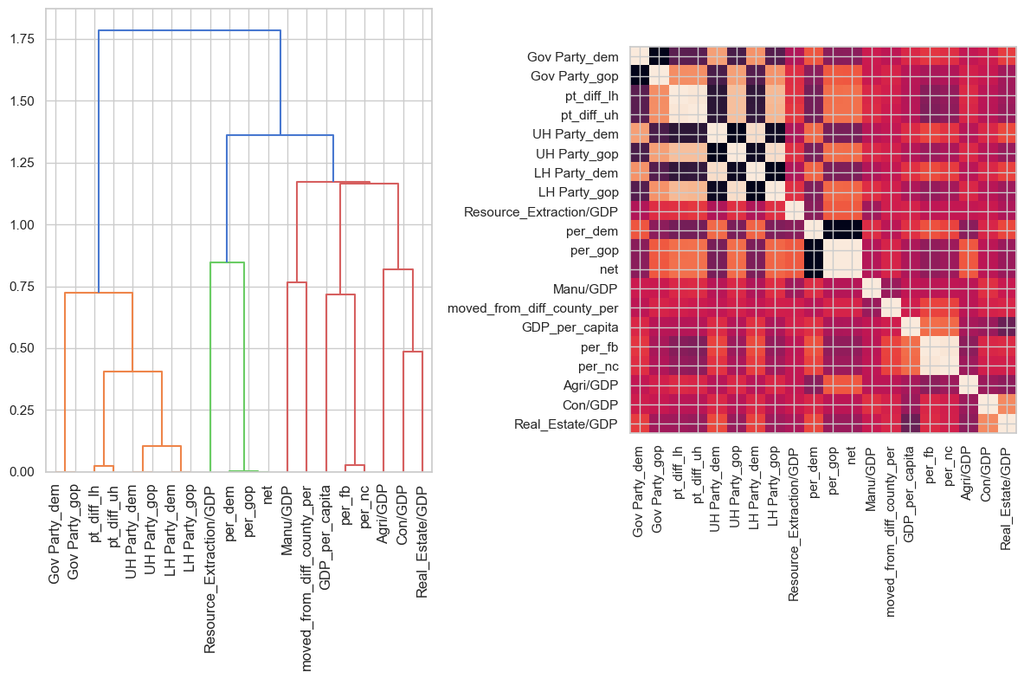

```python
#| include: false
def plot_permutation_importance(clf, X, y, ax):
    result = permutation_importance(clf, X, y, n_repeats=10, random_state=42, n_jobs=2)
    perm_sorted_idx = result.importances_mean.argsort()
    tick_labels_parameter_name = ("tick_labels")
    tick_labels_dict = {tick_labels_parameter_name: X.columns[perm_sorted_idx]}
    ax.boxplot(result.importances[perm_sorted_idx].T, vert=False, **tick_labels_dict)
    ax.axvline(x=0, color="k", linestyle="--")
    return ax


corr_mat = x9_all.corr(method = 'spearman')


# corr_mat.style.background_gradient(cmap='coolwarm', axis = None)

fig, (ax1, ax2) = plt.subplots(1, 2, figsize=(12, 8))

distance_matrix = 1 - np.abs(corr_mat)
dist_linkage = hierarchy.ward(squareform(distance_matrix))
dendro = hierarchy.dendrogram(
    dist_linkage, labels=x9_all.columns.to_list(), ax=ax1, leaf_rotation=90
)
dendro_idx = np.arange(0, len(dendro["ivl"]))

corr_array = corr_mat.to_numpy()

ax2.imshow(corr_array[dendro["leaves"], :][:, dendro["leaves"]])
ax2.set_xticks(dendro_idx)
ax2.set_yticks(dendro_idx)
ax2.set_xticklabels(dendro["ivl"], rotation="vertical")
ax2.set_yticklabels(dendro["ivl"])
_ = fig.tight_layout()
```

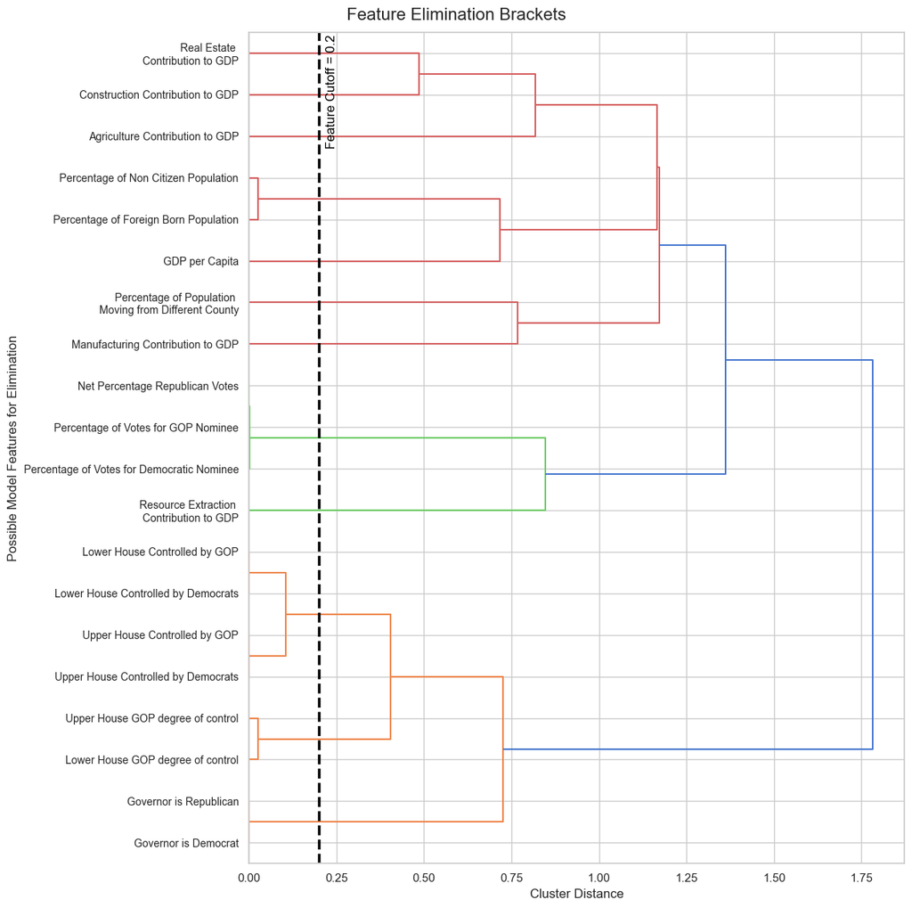

```python
#| echo: false

# 1) Compute clustering as before
corr_mat = x9_all.corr(method="spearman")
distance_matrix = 1 - np.abs(corr_mat)
linkage = hierarchy.ward(squareform(distance_matrix))

# 2) Update display labels
display_map = {
    "Real_Estate/GDP": "Real Estate \nContribution to GDP",
    "Resource_Extraction/GDP": "Resource Extraction \nContribution to GDP",
    "Con/GDP": "Construction Contribution to GDP",
    "Agri/GDP": "Agriculture Contribution to GDP",
    "Manu/GDP": "Manufacturing Contribution to GDP",
    "GDP_per_capita": "GDP per Capita",
    "per_gop": "Percentage of Votes for GOP Nominee",
    "per_dem": "Percentage of Votes for Democratic Nominee",
    "net": "Net Percentage Republican Votes",
    "per_nc": "Percentage of Non Citizen Population",
    "per_fb": "Percentage of Foreign Born Population",
    "moved_from_diff_county_per": "Percentage of Population \nMoving from Different County",
    "LH Party_gop": "Lower House Controlled by GOP",
    "LH Party_dem": "Lower House Controlled by Democrats",
    "UH Party_gop": "Upper House Controlled by GOP",
    "UH Party_dem": "Upper House Controlled by Democrats",
    "pt_diff_lh": "Lower House GOP degree of control",
    "pt_diff_uh": "Upper House GOP degree of control",
    "Gov Party_gop": "Governor is Republican",
    "Gov Party_dem": "Governor is Democrat",
}

labels = [display_map.get(col, col) for col in corr_mat.columns]

# 3) Plot horizontal dendrogram (features on Y, distance on X)
fig, ax = plt.subplots(figsize=(12, 12))
hierarchy.dendrogram(
    linkage,
    labels=labels,        # <- use mapped labels
    orientation="right",
    leaf_font_size=10
)

# Axis labels
ax.set_xlabel("Cluster Distance")
ax.set_ylabel("Possible Model Features for Elimination")

# Title
plt.suptitle('Feature Elimination Brackets', fontsize=16)

# Add vertical cutoff line
ax.axvline(
    x=0.2, color='black', linewidth=2.5, linestyle='--',
    label='Feature Cutoff'
)

# Add text label near the line
ax.text(
    0.2 + 0.02,           # x position slightly right of the line
    ax.get_ylim()[1] - 0.5,  # y position near the top
    'Feature Cutoff = 0.2',
    rotation=90,
    verticalalignment='top',
    fontsize=12,
    color='black'
)

plt.tight_layout()
plt.show()
```

Using Ward’s linkage from the SciPy library, we found that some features were highly similar in the vector space. We settled on a distance threshold of 0.2 after brief testing, which led to the removal of the upper house of the state Legislature, or Senate, and the use of numbers associated with the lower house, or House, in the final feature space. The percentage of non-citizens in the population was also removed as it was highly correlated with the rate of foreign-born individuals in the population.

```python
#| include: false
dist = squareform(1 - corr_mat)
dist_linkage = hierarchy.linkage(dist, method='average')

data = {}
for i in range(2):
    threshold = i * .2
    cluster_ids = hierarchy.fcluster(dist_linkage, threshold, criterion="distance")
    cluster_id_to_feature_ids = defaultdict(list)
    for idx, cluster_id in enumerate(cluster_ids):
        cluster_id_to_feature_ids[cluster_id].append(idx)
    selected_features = [v[0] for v in cluster_id_to_feature_ids.values()]
    selected_features_names = x9_all.columns[selected_features]

    points_list = []
    for point in ilrc_points:
        y = agg_data_norm_plus[point]
        X_train, X_test, y_train, y_test = train_test_split(x9_all, y, random_state=seed)

        X_train_sel = X_train[selected_features_names]
        X_test_sel = X_test[selected_features_names]

        # clf = GradientBoostingClassifier(learning_rate=lr)
        # clf.fit(X_train, y_train)

        clf_sel = GradientBoostingClassifier(learning_rate=lr)
        clf_sel.fit(X_train_sel, y_train)

        # y_pred = clf.predict(X_test)
        # f1 = f1_score(y_test, y_pred)

        y_pred_sel = clf_sel.predict(X_test_sel)
        f1_sel = f1_score(y_test, y_pred_sel)

        points_list.append(f1_sel)

    ### Uncomment to plot permutation importance for each threshold
    # fig, ax = plt.subplots(figsize=(7, 6))
    # plot_permutation_importance(clf_sel, X_test_sel, y_test, ax)
    # title = "Permutation Importances on selected subset of features\n(test set) for: " + point
    # ax.set_title(title)
    # ax.set_xlabel("Decrease in accuracy score")
    # ax.figure.tight_layout()
    # plt.show()
    data[threshold] = points_list
```

We used the permutation_importance function from the scikit-learn library to determine the importance of each feature in the model. The permutation importance measures the decrease in model performance when a feature’s values are randomly shuffled, which disrupts the relationship between that feature and the target variable.

::: {.content-hidden}

| Policy | Threshold: 0.2 | Threshold: 0.4 | Threshold: 0.6 |
| --- | --- | --- | --- |
| Declines ICE contract | 0.96 | 0.96 | 0.96 |
| Limits ICE holds | 0.80 | **0.81** | 0.80 |
| Limits ICE notifications | 0.75 | 0.75 | 0.75 |
| Limits ICE interrogation | 0.84 | **0.85** | 0.83 |
| Prohibit asking status | **0.91** | **0.91** | 0.90 |
| General prohibit on assistance | 0.98 | 0.98 | 0.98 |

:::

```python
#| include: False
import_frame = pd.DataFrame()

for point in ilrc_points:
        y = agg_data_norm_plus[point]
        X_train, X_test, y_train, y_test = train_test_split(x9_all, y, random_state=seed)
        X_train_sel = X_train[selected_features_names]
        X_test_sel = X_test[selected_features_names]
        clf_sel = GradientBoostingClassifier(learning_rate=lr).fit(X_train_sel, y_train)
        clf_sel.fit(X_train_sel, y_train)
        y_pred_sel = clf_sel.predict(X_test_sel)
        f1_sel = f1_score(y_test, y_pred_sel)
        result = permutation_importance(clf_sel, X_test_sel, y_test, scoring='f1', n_repeats=10, random_state=seed, n_jobs=2)
        importances = pd.Series(result.importances_mean, index = selected_features_names, name = point)
        import_frame = pd.concat([import_frame, importances], axis = 1)
```

```python
#| include: False
import_frame = pd.DataFrame()

clf_sel = GradientBoostingClassifier(learning_rate=lr)

for point in ilrc_points:
        y = agg_data_norm_plus[point]
        X_train, X_test, y_train, y_test = train_test_split(x9_all, y, random_state=seed)
        X_train_sel = X_train[selected_features_names]
        X_test_sel = X_test[selected_features_names]
        clf_sel.fit(X_train_sel, y_train)
        y_pred_sel = clf_sel.predict(X_test_sel)
        f1_sel = f1_score(y_test, y_pred_sel)
        result = permutation_importance(clf_sel, X_test_sel, y_test, scoring='f1', n_repeats=10, random_state=42, n_jobs=2)
        importances = pd.Series(result.importances_mean, index = selected_features_names, name = point)
        import_frame = pd.concat([import_frame, importances], axis = 1)
```

```python
#| include: false

print(point)
perm_sorted_idx = result.importances_mean.argsort()
result.importances[perm_sorted_idx].T
```

```
general_prohibit_on_assistance
```

[output not shown]

### Results

The degree of which a political party controls the state Legislature is the strongest predictor of the policies comprising the ILRC score. The GradientBoostingClassifier performed best overall, with an F1 score of 0.98 for the passive policies and 0.81 for the active policies.

The predictive power of the model is limited by the data available, as the ILRC score is a composite of seven policies, some of which are more difficult to predict than others. The active policies had stronger associations with the net political affiliation of the lower house of the state Legislature, which is to say if the state's lower house is more universally Republican the counties associated with that state are more likely to have a specific policy outcome, similarly to how states with a lower house that is more universally Democrats, the counties associated with that state will have the opposite specific policy outcome.

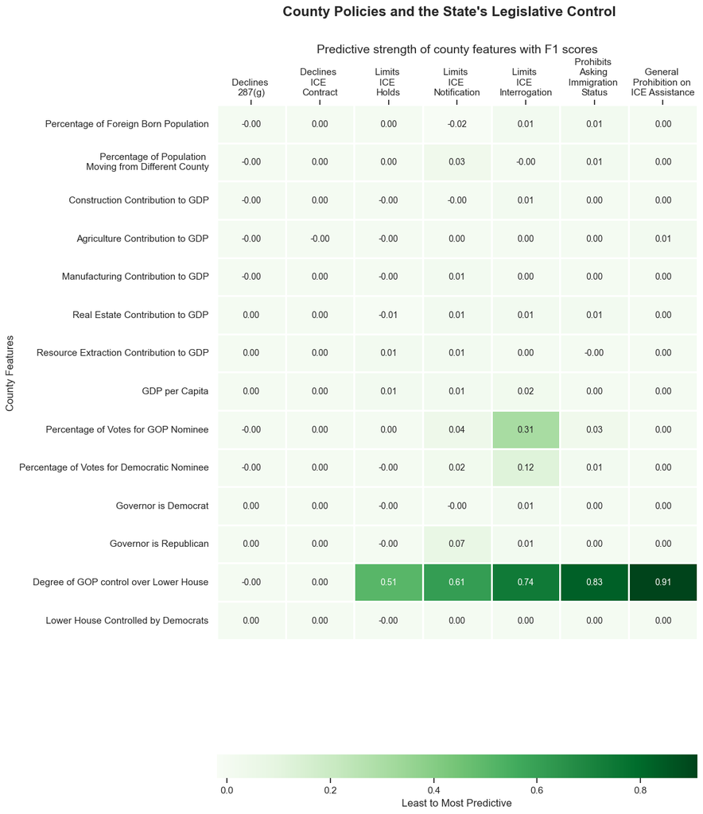

```python
#| echo: False

# Prepare figure
plt.figure(figsize=(10, 16))

# Ordering the rows
ordered_rows = [
    # Census Data
    'per_fb',
    'moved_from_diff_county_per',

    # Economic Data
    'Con/GDP',
    'Agri/GDP',
    'Manu/GDP',
    'Real_Estate/GDP',
    'Resource_Extraction/GDP',
    'GDP_per_capita',

    # Election Data
    'per_gop',
    'per_dem',
    'Gov Party_dem',
    'Gov Party_gop',
    'pt_diff_lh',
    'LH Party_dem'
]

display_map2 = {
    "Real_Estate/GDP": "Real Estate Contribution to GDP",
    "Resource_Extraction/GDP": "Resource Extraction Contribution to GDP",
    "Con/GDP": "Construction Contribution to GDP",
    "Agri/GDP": "Agriculture Contribution to GDP",
    "Manu/GDP": "Manufacturing Contribution to GDP",
    "GDP_per_capita": "GDP per Capita",
    "per_gop": "Percentage of Votes for GOP Nominee",
    "per_dem": "Percentage of Votes for Democratic Nominee",
    "net": "Net Percentage Republican Votes",
    "per_nc": "Percentage of Non Citizen Population",
    "per_fb": "Percentage of Foreign Born Population",
    "moved_from_diff_county_per": "Percentage of Population \nMoving from Different County",
    "LH Party_gop": "Lower House Controlled by GOP",
    "LH Party_dem": "Lower House Controlled by Democrats",
    "UH Party_gop": "Upper House Controlled by GOP",
    "UH Party_dem": "Upper House Controlled by Democrats",
    "pt_diff_lh": "Degree of GOP control over Lower House",
    "pt_diff_uh": "Degree of GOP control over Upper House",
    "Gov Party_gop": "Governor is Republican",
    "Gov Party_dem": "Governor is Democrat",
}


# Filter the frame to only the ordered rows you want to show
import_frame_rounded = (
    import_frame
    .loc[ordered_rows]
    .fillna(0)
    .round(2)
)

# Plot using only those rows, and map labels
ax = sns.heatmap(
    data=import_frame_rounded,
    annot=True,
    fmt=".2f",
    cmap=cmap,
    linewidths=1,
    linecolor='white',
    annot_kws={"size": 10},
    cbar_kws={'orientation': 'horizontal', 'label': 'Least to Most Predictive'},
    yticklabels=[display_map2.get(idx, idx) for idx in ordered_rows],  # <- match filtered order
    xticklabels=[
        'Declines \n287(g)',
        'Declines \nICE \nContract',
        'Limits \nICE \nHolds',
        'Limits \nICE \nNotification',
        'Limits \nICE \nInterrogation',
        'Prohibits \nAsking \nImmigration \nStatus',
        'General \nProhibition on \nICE Assistance'
    ],
)

# Rotate column labels
plt.xticks(ha='center')
ax.xaxis.set_ticks_position('top')  # move labels to top
ax.xaxis.set_label_position('top')  # move label to top


# Show Plot
plt.suptitle('County Policies and the State\'s Legislative Control', size=16, weight='bold')
plt.title('Predictive strength of county features with F1 scores', size=14)
plt.ylabel('County Features')
plt.show()
```

## Conclusion

The objectives of this project were to look at what counties with similar immigration policies have in common. We have found that for active policies the most important features are the difference between the proportion of Republican control and proportion of Democratic control in the lower house of the state Legislature. This research makes no claim about causation between the support for Republican state legislators and restrictive immigration policy because we lacked time series data concerning the changes in immigration policies.

The ethical implications of this research include the risk that the findings be misunderstood as predictive or causal instead of correlated.

## Future Research

While navigating this project, we identified several improvements as future research opportunities that could add new light to how we understand what marginal changes can result in the most significant shifts in county-level immigration policies.

**Education Policies**

There are differences in state policies regarding whether non-citizens can receive in-state higher education tuition. This could be explored as a feature for as either a predictive feature similar to the voting behaviors and demographics, or as an output variable on the broader theme of inclusivity and integration.

**Comment Text Analysis**

In the ILRC data, cach county is annotated with comments that could add insights regarding which branch of government is most active in policy changes. For example, the comments for Multnomah County are:

- **2015 ICE Comments:** Ground Zero for detainer issues, County for Portland, OR, adjacent to Clackamas County, which was the subject of Miranda-Olivares. Awaiting response from the County concerning the future meeting on PEP. 09/28/2015 Update: The Oregon USAO is hosting a meeting with representatives from Clackamas, Marion, Multnomah, and Washington counties, including sheriffs, district attorneys, county counsels, and others, to discuss PEP. DEAD B(6) B(7)C and AFODs B(6) B(7)C will be participating.
- **2017 ICE Comments:** Basis of policy refined to more accurately reflect understanding of Oregon State Sheriff’s Association (OSSA) position and respective Sheriff’s policy as it has evolved: Does not provide foreign-born arrest information. It will allow ICE access to interview an alien. Will honor the 48-hour hold provision of I-247A only with a criminal warrant issued by the USDC. Miranda-Olivares v. Clackamas County cited as prohibiting compliance with DHS administrative detainers. Will not allow transfer of custody within the secure area of the facility. ORS 181A.820 is cited as prohibiting the transfer of custody and ongoing exchange of information, including the release of information.

Further research could be done to analyze the comments and identify patterns in the language used by counties with different ILRC scores. This could provide additional insights into the motivations and concerns of local governments, as well as how elected judges and other officials may influence the implementation of sanctuary policies. For example, Miranda-Olivares v. Clackamas County is cited for all counties in Oregon, whereas states with lower scores do not cite similar rulings in the comments to similar degrees.

**Unemployment Rate**

Beyond the industry activity for individual counties, additional research could be done to look at how unemployment rates may be associated with the ILRC score. The unemployment rate is a key economic indicator that could predict voter outlooks and preferences reflected in immigration policies.

**Population Diversity**

The diversity of the population in a county could be another factor to consider. Counties with higher proportions of foreign-born residents or non-citizens may have different perspectives on immigration policies.

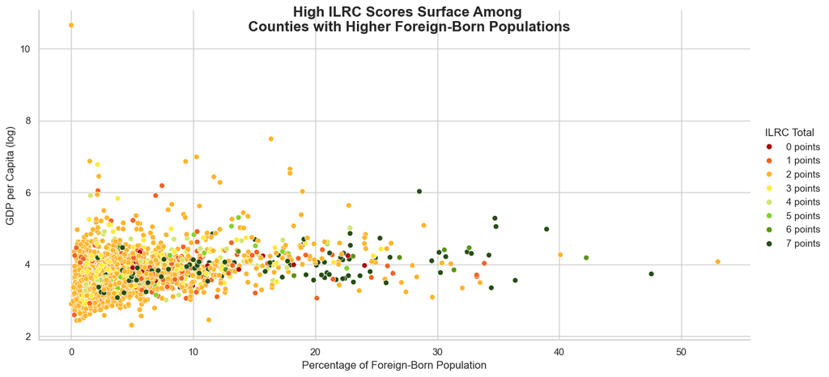

```python
#| echo: false
# Exploratory Data Analysis

# Does the relationship between foreign-born population and GDP per capita vary by ILRC score?
agg_data_norm['log_GDP_per_capita'] = np.where(agg_data_norm['GDP_per_capita'] > 0, np.log(agg_data_norm['GDP_per_capita']), 0)



# Create a scatter plot to visualize the relationship
sns.relplot(
    data=agg_data_norm,
    x='per_fb',
    y='log_GDP_per_capita',
    hue='ILRC Total',
    palette=ilrc_colors,
    height=6,
    aspect=2,
)



# Set the title and labels
plt.suptitle('High ILRC Scores Surface Among \nCounties with Higher Foreign-Born Populations', fontsize=16, weight='bold')
plt.xlabel('Percentage of Foreign-Born Population')
plt.ylabel('GDP per Capita (log)')
plt.grid(True)
plt.show()
```

```python
#| include: false

# Identify the outlier county with GDP per capita greater than 40k
print(agg_data_norm[agg_data_norm['GDP_per_capita'] > 40000])

# FIPS code 48301 represents Loving County, Texas
# Loving County has a GDP per capita of 46,000 with an estimated population of 64 people in the 2020 census due to oil extraction.
```

```
     fips_code state    per_gop    per_dem        net ILRC Total  \
2504     48301    48  87.567568  10.540541  77.027027   2 points

      declines_287  declines_ICE_contract  limits_ICE_hold  limits_ICE_notif  \
2504             1                      1                0                 0

      ...   Con/GDP  Agri/GDP  Manu/GDP  Real_Estate/GDP  \
2504  ...  0.000074  0.022832  0.007266         0.009878

      Resource_Extraction/GDP  GDP_per_capita  per_fb  per_nc  \
2504                 77.21216    42448.154023     0.0     0.0

      moved_from_diff_county_per  log_GDP_per_capita
2504                    6.896552           10.656039

[1 rows x 23 columns]
```

**FBI Crime Statistics**

The FBI crime statistics could be used to look at the relationship between crime rates and ILRC scores. This could provide additional insights into how local governments perceive the relationship between crime rates and immigration policies.

### Data Sources

| **Category** | **Description** | **Link** |
| --- | --- | --- |
| **Immigration Policy Data** | ILRC immigration policy data by county | [Datawrapper](https://www.datawrapper.de/_/082cz/) |
| **Census Population Data** | ACS 5-Year population and migration estimates | [U.S. Census Bureau](https://www.census.gov/data/developers/data-sets/acs-5year.html) |
| **Economic Data** | GDP by industry and state | [BEA (Bureau of Economic Analysis)](https://www.bea.gov/itable/gdp-by-industry) |
| **Federal Elections Data** | U.S. county-level federal election results (2008–2024) | [GitHub - tonmcg](https://github.com/tonmcg/US_County_Level_Election_Results_08-24) |
| **Governor Data** | List of current U.S. governors | [Wikipedia](https://en.wikipedia.org/wiki/List_of_current_United_States_governors#cite_note-NGA-Roster-12) |
| **State Legislature Data** | Composition of state Legislatures | [Wikipedia](https://en.wikipedia.org/wiki/List_of_United_States_state_legislatures) |